# House Price Kaggle

During my work on this project I found inspiration in following kernels found on Kaggle:

https://www.kaggle.com/pmarcelino/comprehensive-data-exploration-with-python

https://www.kaggle.com/serigne/stacked-regressions-top-4-on-leaderboard

https://www.kaggle.com/poonaml/house-prices-data-exploration-and-visualisation

https://www.kaggle.com/dfitzgerald3/randomforestregressor

https://www.kaggle.com/meikegw/filling-up-missing-values

Keras, ... https://www.kaggle.com/apapiu/regularized-linear-models

# The data

Data are in two files in CVS format.

- train.csv consist of labeled data points with 80 features.
- test.csv consist of unlabeled data points

```python
# Import libraries necessary for this project
import numpy as np
import pandas as pd
from sklearn.model_selection import ShuffleSplit

# Pretty display for notebooks
%matplotlib inline

# Load the Boston housing dataset
data_train = pd.read_csv('data\\train.csv')
data_test = pd.read_csv('data\\test.csv')

# Success
print "Kaggle 'House prices'  TRAIN dataset has {} data points with {} variables each.".format(*data_train.shape)
print "Kaggle 'House prices'  TEST dataset has {} data points with {} variables each.".format(*data_test.shape)
```

```
Kaggle 'House prices'  TRAIN dataset has 1460 data points with 81 variables each.
Kaggle 'House prices'  TEST dataset has 1459 data points with 80 variables each.
```

```python
data_train
```

|  | Id | MSSubClass | MSZoning | LotFrontage | LotArea | Street | Alley | LotShape | LandContour | Utilities | ... | PoolArea | PoolQC | Fence | MiscFeature | MiscVal | MoSold | YrSold | SaleType | SaleCondition | SalePrice |
| --- | --- | --- | --- | --- | --- | --- | --- | --- | --- | --- | --- | --- | --- | --- | --- | --- | --- | --- | --- | --- | --- |
| 0 | 1 | 60 | RL | 65.0 | 8450 | Pave | NaN | Reg | Lvl | AllPub | ... | 0 | NaN | NaN | NaN | 0 | 2 | 2008 | WD | Normal | 208500 |
| 1 | 2 | 20 | RL | 80.0 | 9600 | Pave | NaN | Reg | Lvl | AllPub | ... | 0 | NaN | NaN | NaN | 0 | 5 | 2007 | WD | Normal | 181500 |
| 2 | 3 | 60 | RL | 68.0 | 11250 | Pave | NaN | IR1 | Lvl | AllPub | ... | 0 | NaN | NaN | NaN | 0 | 9 | 2008 | WD | Normal | 223500 |
| 3 | 4 | 70 | RL | 60.0 | 9550 | Pave | NaN | IR1 | Lvl | AllPub | ... | 0 | NaN | NaN | NaN | 0 | 2 | 2006 | WD | Abnorml | 140000 |
| 4 | 5 | 60 | RL | 84.0 | 14260 | Pave | NaN | IR1 | Lvl | AllPub | ... | 0 | NaN | NaN | NaN | 0 | 12 | 2008 | WD | Normal | 250000 |
| 5 | 6 | 50 | RL | 85.0 | 14115 | Pave | NaN | IR1 | Lvl | AllPub | ... | 0 | NaN | MnPrv | Shed | 700 | 10 | 2009 | WD | Normal | 143000 |
| 6 | 7 | 20 | RL | 75.0 | 10084 | Pave | NaN | Reg | Lvl | AllPub | ... | 0 | NaN | NaN | NaN | 0 | 8 | 2007 | WD | Normal | 307000 |
| 7 | 8 | 60 | RL | NaN | 10382 | Pave | NaN | IR1 | Lvl | AllPub | ... | 0 | NaN | NaN | Shed | 350 | 11 | 2009 | WD | Normal | 200000 |
| 8 | 9 | 50 | RM | 51.0 | 6120 | Pave | NaN | Reg | Lvl | AllPub | ... | 0 | NaN | NaN | NaN | 0 | 4 | 2008 | WD | Abnorml | 129900 |
| 9 | 10 | 190 | RL | 50.0 | 7420 | Pave | NaN | Reg | Lvl | AllPub | ... | 0 | NaN | NaN | NaN | 0 | 1 | 2008 | WD | Normal | 118000 |
| 10 | 11 | 20 | RL | 70.0 | 11200 | Pave | NaN | Reg | Lvl | AllPub | ... | 0 | NaN | NaN | NaN | 0 | 2 | 2008 | WD | Normal | 129500 |
| 11 | 12 | 60 | RL | 85.0 | 11924 | Pave | NaN | IR1 | Lvl | AllPub | ... | 0 | NaN | NaN | NaN | 0 | 7 | 2006 | New | Partial | 345000 |
| 12 | 13 | 20 | RL | NaN | 12968 | Pave | NaN | IR2 | Lvl | AllPub | ... | 0 | NaN | NaN | NaN | 0 | 9 | 2008 | WD | Normal | 144000 |
| 13 | 14 | 20 | RL | 91.0 | 10652 | Pave | NaN | IR1 | Lvl | AllPub | ... | 0 | NaN | NaN | NaN | 0 | 8 | 2007 | New | Partial | 279500 |
| 14 | 15 | 20 | RL | NaN | 10920 | Pave | NaN | IR1 | Lvl | AllPub | ... | 0 | NaN | GdWo | NaN | 0 | 5 | 2008 | WD | Normal | 157000 |
| 15 | 16 | 45 | RM | 51.0 | 6120 | Pave | NaN | Reg | Lvl | AllPub | ... | 0 | NaN | GdPrv | NaN | 0 | 7 | 2007 | WD | Normal | 132000 |
| 16 | 17 | 20 | RL | NaN | 11241 | Pave | NaN | IR1 | Lvl | AllPub | ... | 0 | NaN | NaN | Shed | 700 | 3 | 2010 | WD | Normal | 149000 |
| 17 | 18 | 90 | RL | 72.0 | 10791 | Pave | NaN | Reg | Lvl | AllPub | ... | 0 | NaN | NaN | Shed | 500 | 10 | 2006 | WD | Normal | 90000 |
| 18 | 19 | 20 | RL | 66.0 | 13695 | Pave | NaN | Reg | Lvl | AllPub | ... | 0 | NaN | NaN | NaN | 0 | 6 | 2008 | WD | Normal | 159000 |
| 19 | 20 | 20 | RL | 70.0 | 7560 | Pave | NaN | Reg | Lvl | AllPub | ... | 0 | NaN | MnPrv | NaN | 0 | 5 | 2009 | COD | Abnorml | 139000 |
| 20 | 21 | 60 | RL | 101.0 | 14215 | Pave | NaN | IR1 | Lvl | AllPub | ... | 0 | NaN | NaN | NaN | 0 | 11 | 2006 | New | Partial | 325300 |
| 21 | 22 | 45 | RM | 57.0 | 7449 | Pave | Grvl | Reg | Bnk | AllPub | ... | 0 | NaN | GdPrv | NaN | 0 | 6 | 2007 | WD | Normal | 139400 |
| 22 | 23 | 20 | RL | 75.0 | 9742 | Pave | NaN | Reg | Lvl | AllPub | ... | 0 | NaN | NaN | NaN | 0 | 9 | 2008 | WD | Normal | 230000 |
| 23 | 24 | 120 | RM | 44.0 | 4224 | Pave | NaN | Reg | Lvl | AllPub | ... | 0 | NaN | NaN | NaN | 0 | 6 | 2007 | WD | Normal | 129900 |
| 24 | 25 | 20 | RL | NaN | 8246 | Pave | NaN | IR1 | Lvl | AllPub | ... | 0 | NaN | MnPrv | NaN | 0 | 5 | 2010 | WD | Normal | 154000 |
| 25 | 26 | 20 | RL | 110.0 | 14230 | Pave | NaN | Reg | Lvl | AllPub | ... | 0 | NaN | NaN | NaN | 0 | 7 | 2009 | WD | Normal | 256300 |
| 26 | 27 | 20 | RL | 60.0 | 7200 | Pave | NaN | Reg | Lvl | AllPub | ... | 0 | NaN | NaN | NaN | 0 | 5 | 2010 | WD | Normal | 134800 |
| 27 | 28 | 20 | RL | 98.0 | 11478 | Pave | NaN | Reg | Lvl | AllPub | ... | 0 | NaN | NaN | NaN | 0 | 5 | 2010 | WD | Normal | 306000 |
| 28 | 29 | 20 | RL | 47.0 | 16321 | Pave | NaN | IR1 | Lvl | AllPub | ... | 0 | NaN | NaN | NaN | 0 | 12 | 2006 | WD | Normal | 207500 |
| 29 | 30 | 30 | RM | 60.0 | 6324 | Pave | NaN | IR1 | Lvl | AllPub | ... | 0 | NaN | NaN | NaN | 0 | 5 | 2008 | WD | Normal | 68500 |
| ... | ... | ... | ... | ... | ... | ... | ... | ... | ... | ... | ... | ... | ... | ... | ... | ... | ... | ... | ... | ... | ... |
| 1430 | 1431 | 60 | RL | 60.0 | 21930 | Pave | NaN | IR3 | Lvl | AllPub | ... | 0 | NaN | NaN | NaN | 0 | 7 | 2006 | WD | Normal | 192140 |
| 1431 | 1432 | 120 | RL | NaN | 4928 | Pave | NaN | IR1 | Lvl | AllPub | ... | 0 | NaN | NaN | NaN | 0 | 10 | 2009 | WD | Normal | 143750 |
| 1432 | 1433 | 30 | RL | 60.0 | 10800 | Pave | Grvl | Reg | Lvl | AllPub | ... | 0 | NaN | NaN | NaN | 0 | 8 | 2007 | WD | Normal | 64500 |
| 1433 | 1434 | 60 | RL | 93.0 | 10261 | Pave | NaN | IR1 | Lvl | AllPub | ... | 0 | NaN | NaN | NaN | 0 | 5 | 2008 | WD | Normal | 186500 |
| 1434 | 1435 | 20 | RL | 80.0 | 17400 | Pave | NaN | Reg | Low | AllPub | ... | 0 | NaN | NaN | NaN | 0 | 5 | 2006 | WD | Normal | 160000 |
| 1435 | 1436 | 20 | RL | 80.0 | 8400 | Pave | NaN | Reg | Lvl | AllPub | ... | 0 | NaN | GdPrv | NaN | 0 | 7 | 2008 | COD | Abnorml | 174000 |
| 1436 | 1437 | 20 | RL | 60.0 | 9000 | Pave | NaN | Reg | Lvl | AllPub | ... | 0 | NaN | GdWo | NaN | 0 | 5 | 2007 | WD | Normal | 120500 |
| 1437 | 1438 | 20 | RL | 96.0 | 12444 | Pave | NaN | Reg | Lvl | AllPub | ... | 0 | NaN | NaN | NaN | 0 | 11 | 2008 | New | Partial | 394617 |
| 1438 | 1439 | 20 | RM | 90.0 | 7407 | Pave | NaN | Reg | Lvl | AllPub | ... | 0 | NaN | MnPrv | NaN | 0 | 4 | 2010 | WD | Normal | 149700 |
| 1439 | 1440 | 60 | RL | 80.0 | 11584 | Pave | NaN | Reg | Lvl | AllPub | ... | 0 | NaN | NaN | NaN | 0 | 11 | 2007 | WD | Normal | 197000 |
| 1440 | 1441 | 70 | RL | 79.0 | 11526 | Pave | NaN | IR1 | Bnk | AllPub | ... | 0 | NaN | NaN | NaN | 0 | 9 | 2008 | WD | Normal | 191000 |
| 1441 | 1442 | 120 | RM | NaN | 4426 | Pave | NaN | Reg | Lvl | AllPub | ... | 0 | NaN | NaN | NaN | 0 | 5 | 2008 | WD | Normal | 149300 |
| 1442 | 1443 | 60 | FV | 85.0 | 11003 | Pave | NaN | Reg | Lvl | AllPub | ... | 0 | NaN | NaN | NaN | 0 | 4 | 2009 | WD | Normal | 310000 |
| 1443 | 1444 | 30 | RL | NaN | 8854 | Pave | NaN | Reg | Lvl | AllPub | ... | 0 | NaN | NaN | NaN | 0 | 5 | 2009 | WD | Normal | 121000 |
| 1444 | 1445 | 20 | RL | 63.0 | 8500 | Pave | NaN | Reg | Lvl | AllPub | ... | 0 | NaN | NaN | NaN | 0 | 11 | 2007 | WD | Normal | 179600 |
| 1445 | 1446 | 85 | RL | 70.0 | 8400 | Pave | NaN | Reg | Lvl | AllPub | ... | 0 | NaN | NaN | NaN | 0 | 5 | 2007 | WD | Normal | 129000 |
| 1446 | 1447 | 20 | RL | NaN | 26142 | Pave | NaN | IR1 | Lvl | AllPub | ... | 0 | NaN | NaN | NaN | 0 | 4 | 2010 | WD | Normal | 157900 |
| 1447 | 1448 | 60 | RL | 80.0 | 10000 | Pave | NaN | Reg | Lvl | AllPub | ... | 0 | NaN | NaN | NaN | 0 | 12 | 2007 | WD | Normal | 240000 |
| 1448 | 1449 | 50 | RL | 70.0 | 11767 | Pave | NaN | Reg | Lvl | AllPub | ... | 0 | NaN | GdWo | NaN | 0 | 5 | 2007 | WD | Normal | 112000 |
| 1449 | 1450 | 180 | RM | 21.0 | 1533 | Pave | NaN | Reg | Lvl | AllPub | ... | 0 | NaN | NaN | NaN | 0 | 8 | 2006 | WD | Abnorml | 92000 |
| 1450 | 1451 | 90 | RL | 60.0 | 9000 | Pave | NaN | Reg | Lvl | AllPub | ... | 0 | NaN | NaN | NaN | 0 | 9 | 2009 | WD | Normal | 136000 |
| 1451 | 1452 | 20 | RL | 78.0 | 9262 | Pave | NaN | Reg | Lvl | AllPub | ... | 0 | NaN | NaN | NaN | 0 | 5 | 2009 | New | Partial | 287090 |
| 1452 | 1453 | 180 | RM | 35.0 | 3675 | Pave | NaN | Reg | Lvl | AllPub | ... | 0 | NaN | NaN | NaN | 0 | 5 | 2006 | WD | Normal | 145000 |
| 1453 | 1454 | 20 | RL | 90.0 | 17217 | Pave | NaN | Reg | Lvl | AllPub | ... | 0 | NaN | NaN | NaN | 0 | 7 | 2006 | WD | Abnorml | 84500 |
| 1454 | 1455 | 20 | FV | 62.0 | 7500 | Pave | Pave | Reg | Lvl | AllPub | ... | 0 | NaN | NaN | NaN | 0 | 10 | 2009 | WD | Normal | 185000 |
| 1455 | 1456 | 60 | RL | 62.0 | 7917 | Pave | NaN | Reg | Lvl | AllPub | ... | 0 | NaN | NaN | NaN | 0 | 8 | 2007 | WD | Normal | 175000 |
| 1456 | 1457 | 20 | RL | 85.0 | 13175 | Pave | NaN | Reg | Lvl | AllPub | ... | 0 | NaN | MnPrv | NaN | 0 | 2 | 2010 | WD | Normal | 210000 |
| 1457 | 1458 | 70 | RL | 66.0 | 9042 | Pave | NaN | Reg | Lvl | AllPub | ... | 0 | NaN | GdPrv | Shed | 2500 | 5 | 2010 | WD | Normal | 266500 |
| 1458 | 1459 | 20 | RL | 68.0 | 9717 | Pave | NaN | Reg | Lvl | AllPub | ... | 0 | NaN | NaN | NaN | 0 | 4 | 2010 | WD | Normal | 142125 |
| 1459 | 1460 | 20 | RL | 75.0 | 9937 | Pave | NaN | Reg | Lvl | AllPub | ... | 0 | NaN | NaN | NaN | 0 | 6 | 2008 | WD | Normal | 147500 |

1460 rows × 81 columns

```python
data_train.columns
```

```
Index([u'Id', u'MSSubClass', u'MSZoning', u'LotFrontage', u'LotArea',
       u'Street', u'Alley', u'LotShape', u'LandContour', u'Utilities',
       u'LotConfig', u'LandSlope', u'Neighborhood', u'Condition1',
       u'Condition2', u'BldgType', u'HouseStyle', u'OverallQual',
       u'OverallCond', u'YearBuilt', u'YearRemodAdd', u'RoofStyle',
       u'RoofMatl', u'Exterior1st', u'Exterior2nd', u'MasVnrType',
       u'MasVnrArea', u'ExterQual', u'ExterCond', u'Foundation', u'BsmtQual',
       u'BsmtCond', u'BsmtExposure', u'BsmtFinType1', u'BsmtFinSF1',
       u'BsmtFinType2', u'BsmtFinSF2', u'BsmtUnfSF', u'TotalBsmtSF',
       u'Heating', u'HeatingQC', u'CentralAir', u'Electrical', u'1stFlrSF',
       u'2ndFlrSF', u'LowQualFinSF', u'GrLivArea', u'BsmtFullBath',
       u'BsmtHalfBath', u'FullBath', u'HalfBath', u'BedroomAbvGr',
       u'KitchenAbvGr', u'KitchenQual', u'TotRmsAbvGrd', u'Functional',
       u'Fireplaces', u'FireplaceQu', u'GarageType', u'GarageYrBlt',
       u'GarageFinish', u'GarageCars', u'GarageArea', u'GarageQual',
       u'GarageCond', u'PavedDrive', u'WoodDeckSF', u'OpenPorchSF',
       u'EnclosedPorch', u'3SsnPorch', u'ScreenPorch', u'PoolArea', u'PoolQC',
       u'Fence', u'MiscFeature', u'MiscVal', u'MoSold', u'YrSold', u'SaleType',
       u'SaleCondition', u'SalePrice'],
      dtype='object')
```

```python
import numpy as np
import matplotlib.pyplot as plt
import pandas as pd

%matplotlib inline
```

```python
# time measurement

start_time = 0;

import time

def stopwatch_start():
    global start_time
    start_time = time.time()

def elapsed_time():
    return time.time() - start_time

def print_time(seconds):
    hours = seconds // (60*60)
    seconds %= (60*60)
    minutes = seconds // 60
    seconds %= 60
    return "%02i:%02i:%02i" % (hours, minutes, seconds)

def print_elapsed_time():
    t = print_time(elapsed_time())
    print ("\nElapsed time: {}\n".format(t))
```

## Analysis of sale price 'SalePrice'

```python
stopwatch_start()

prices = data_train['SalePrice']

minimum_price = min(prices)
maximum_price = max(prices)
mean_price = np.mean(prices)
median_price = np.median(prices)

std_price = np.std(prices)

# Show the calculated statistics
print "Statistics for Kaggle House Price dataset:\n"
print "               Maximum price: ${:,.2f}".format(maximum_price)
print "               Minimum price: ${:,.2f}\n".format(minimum_price)
print "               Mean price:    ${:,.2f}".format(mean_price)
print "               Median price   ${:,.2f}\n".format(median_price)
print "Standard deviation of prices: ${:,.2f}".format(std_price)

print_elapsed_time()
```

```
Statistics for Kaggle House Price dataset:

               Maximum price: $755,000.00
               Minimum price: $34,900.00

               Mean price:    $180,921.20
               Median price   $163,000.00

Standard deviation of prices: $79,415.29

Elapsed time: 00:00:00
```

```python
prices.describe()
```

```
count      1460.000000
mean     180921.195890
std       79442.502883
min       34900.000000
25%      129975.000000
50%      163000.000000
75%      214000.000000
max      755000.000000
Name: SalePrice, dtype: float64
```

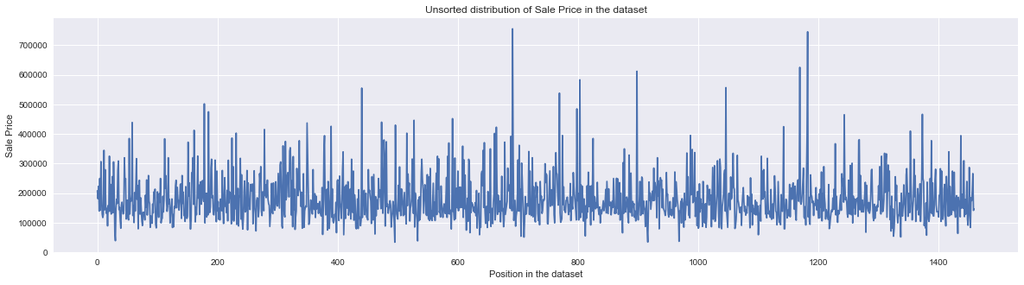

```python
# PLOT distribution of 'SalePrice' in the dataset

plt.figure(figsize=[20,5])
plt.plot(prices)
plt.title("Unsorted distribution of Sale Price in the dataset")
plt.ylabel("Sale Price")
plt.xlabel("Position in the dataset");
plt.show()
```

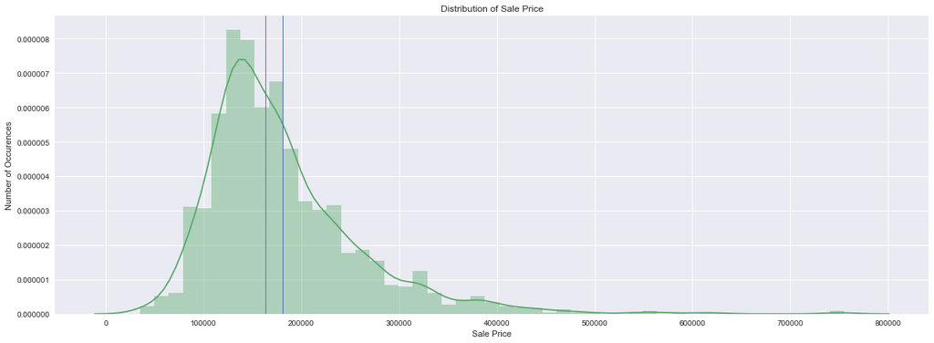

```python
import seaborn as sns

# set size of the graph
plt.subplots(figsize=(20, 7))

ax = sns.distplot(prices, color="g", kde=True )
ax.axvline(prices.mean(),linewidth=1, color='b')
ax.axvline(prices.median(),linewidth=1, color='r')

plt.title("Distribution of Sale Price")
plt.ylabel("Number of Occurences")
plt.xlabel("Sale Price");
plt.show()
```

### Skewness and Kurtosis

**Skewness** is a measure of symmetry, or more precisely, the lack of symmetry. A distribution, or data set, is symmetric if it looks the same to the left and right of the center point.

**Kurtosis** is a measure of whether the data are heavy-tailed or light-tailed relative to a normal distribution. That is, data sets with high kurtosis tend to have heavy tails, or outliers. Data sets with low kurtosis tend to have light tails, or lack of outliers. A uniform distribution would be the extreme case.

Source: http://www.itl.nist.gov/div898/handbook/eda/section3/eda35b.htm

```
           Skewness: 1.8829   Kurtosis: 6.5363
Log scale  Skewness: 0.1213   Kurtosis: 0.8095
```

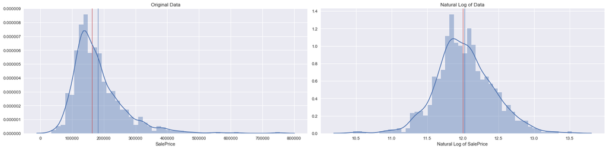

```python
data_name = 'SalePrice'
plot_data = data_train[data_name]
plot_data_log = plot_data.apply(np.log)

plt.figure(figsize=(20,5))
ax = plt.subplot(1,2,1)
ax.axvline(plot_data.mean(),linewidth=1, color='b')
ax.axvline(plot_data.median(),linewidth=1, color='r')
sns.distplot(plot_data, bins=50)
plt.title('Original Data')
plt.xlabel(data_name)

ax = plt.subplot(1,2,2)
sns.distplot(plot_data_log, bins=50)
ax.axvline(plot_data_log.mean(),linewidth=1, color='b')
ax.axvline(plot_data_log.median(),linewidth=1, color='r')
plt.title('Natural Log of Data')
plt.xlabel('Natural Log of {}'.format(data_name))
plt.tight_layout()

print("           Skewness: {0:0.4f}   Kurtosis: {1:0.4f}".format(plot_data.skew(), plot_data.kurt()))
print("Log scale  Skewness: {0:0.4f}   Kurtosis: {1:0.4f}".format(plot_data_log.skew(), plot_data_log.kurt()))
```

```
           Skewness: 12.2077   Kurtosis: 203.2433
Log scale  Skewness: -0.1380   Kurtosis: 4.7134
```

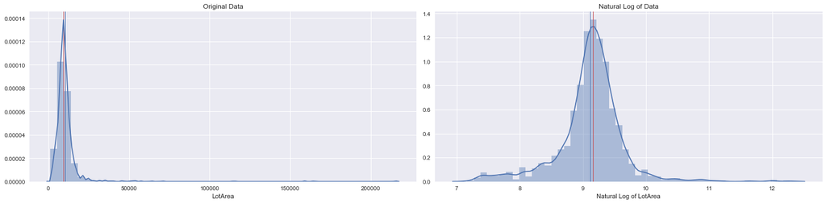

```python
data_name = 'LotArea'
plot_data = data_train[data_name]
plot_data_log = plot_data.apply(np.log)

plt.figure(figsize=(20,5))
ax = plt.subplot(1,2,1)
ax.axvline(plot_data.mean(),linewidth=1, color='b')
ax.axvline(plot_data.median(),linewidth=1, color='r')
sns.distplot(plot_data, bins=50)
plt.title('Original Data')
plt.xlabel(data_name)

ax = plt.subplot(1,2,2)
sns.distplot(plot_data_log, bins=50)
ax.axvline(plot_data_log.mean(),linewidth=1, color='b')
ax.axvline(plot_data_log.median(),linewidth=1, color='r')
plt.title('Natural Log of Data')
plt.xlabel('Natural Log of {}'.format(data_name))
plt.tight_layout()

print("           Skewness: {0:0.4f}   Kurtosis: {1:0.4f}".format(plot_data.skew(), plot_data.kurt()))
print("Log scale  Skewness: {0:0.4f}   Kurtosis: {1:0.4f}".format(plot_data_log.skew(), plot_data_log.kurt()))
```

```
           Skewness: 1.3666   Kurtosis: 4.8951
Log scale  Skewness: -0.0070   Kurtosis: 0.2826
```

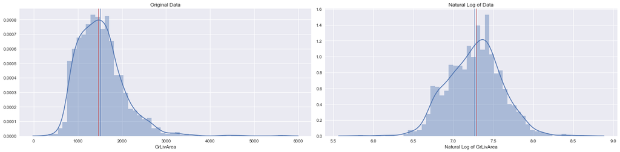

```python
data_name = 'GrLivArea'
plot_data = data_train[data_name]
plot_data_log = plot_data.apply(np.log)

plt.figure(figsize=(20,5))
ax = plt.subplot(1,2,1)
ax.axvline(plot_data.mean(),linewidth=1, color='b')
ax.axvline(plot_data.median(),linewidth=1, color='r')
sns.distplot(plot_data, bins=50)
plt.title('Original Data')
plt.xlabel(data_name)

ax = plt.subplot(1,2,2)
sns.distplot(plot_data_log, bins=50)
ax.axvline(plot_data_log.mean(),linewidth=1, color='b')
ax.axvline(plot_data_log.median(),linewidth=1, color='r')
plt.title('Natural Log of Data')
plt.xlabel('Natural Log of {}'.format(data_name))
plt.tight_layout()

print("           Skewness: {0:0.4f}   Kurtosis: {1:0.4f}".format(plot_data.skew(), plot_data.kurt()))
print("Log scale  Skewness: {0:0.4f}   Kurtosis: {1:0.4f}".format(plot_data_log.skew(), plot_data_log.kurt()))
```

## Linear Regresion on square footage and price

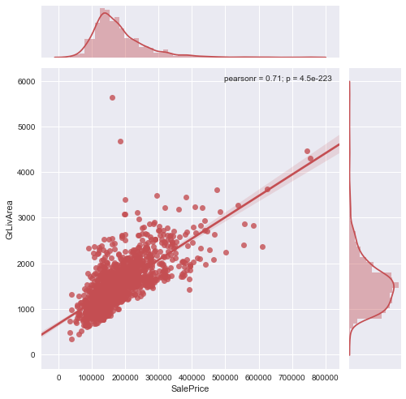

```python
import seaborn as sns
sns.set(style="darkgrid", color_codes=True)

g = sns.jointplot('SalePrice', 'GrLivArea', data=data_train, kind="reg", color="r", size=7)
```

## First prediction - Linear Regression: 'SalePrice' vs. 'GrLivArea'

```python
features = data_train['GrLivArea'].values.reshape(-1,1)
```

```python
from sklearn.linear_model import LinearRegression

model = LinearRegression()
model.fit(features, prices)
predicted = model.predict(features)
```

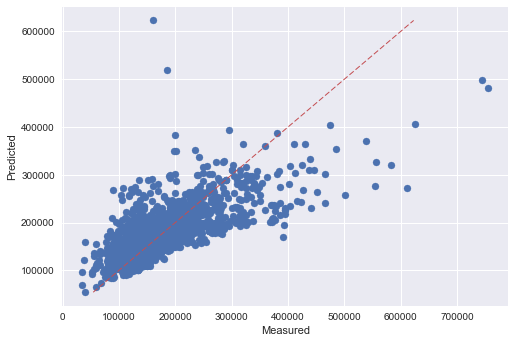

```python
fig, ax = plt.subplots()
ax.scatter(prices, predicted)
ax.plot([predicted.min(),predicted.max()], [predicted.min(), predicted.max()], 'r--', lw=1)
ax.set_xlabel('Measured')
ax.set_ylabel('Predicted')
plt.show()
```

# Metrics

https://www.kaggle.com/wiki/RootMeanSquaredError

```python
import sklearn
from sklearn.metrics import mean_squared_error
from sklearn.metrics import r2_score

def RMSE( y, y_pred):
    return mean_squared_error(y, y_pred)**0.5

def RMSE2(y, y_pred):
    return np.sqrt(np.sum(np.square(y_pred-y))/len(y))

def RMSE3(y, y_pred):
    y = np.log(y)
    y = np.log(y_pred)
    return np.sqrt(np.sum(np.square(y_pred-y))/len(y))

# take all prices as expected values
y = prices
# predicted values are calculated from linear regression
rmse = RMSE2(prices, predicted)
r2score = r2_score(prices, predicted)
print('Root Mean squared error: {:.4f}'.format(rmse, prec=5))
print('R2 score               : {:.6f}'.format(r2score, prec = 5))
```

```
Root Mean squared error: 56034.3039
R2 score               : 0.502149
```

## Correlation

```python
corr=data_train.corr()["SalePrice"]
ccof = corr[np.argsort(corr, axis=0)[::-1]]
ccof
```

```
SalePrice        1.000000
OverallQual      0.790982
GrLivArea        0.708624
GarageCars       0.640409
GarageArea       0.623431
TotalBsmtSF      0.613581
1stFlrSF         0.605852
FullBath         0.560664
TotRmsAbvGrd     0.533723
YearBuilt        0.522897
YearRemodAdd     0.507101
GarageYrBlt      0.486362
MasVnrArea       0.477493
Fireplaces       0.466929
BsmtFinSF1       0.386420
LotFrontage      0.351799
WoodDeckSF       0.324413
2ndFlrSF         0.319334
OpenPorchSF      0.315856
HalfBath         0.284108
LotArea          0.263843
BsmtFullBath     0.227122
BsmtUnfSF        0.214479
BedroomAbvGr     0.168213
ScreenPorch      0.111447
PoolArea         0.092404
MoSold           0.046432
3SsnPorch        0.044584
BsmtFinSF2      -0.011378
BsmtHalfBath    -0.016844
MiscVal         -0.021190
Id              -0.021917
LowQualFinSF    -0.025606
YrSold          -0.028923
OverallCond     -0.077856
MSSubClass      -0.084284
EnclosedPorch   -0.128578
KitchenAbvGr    -0.135907
Name: SalePrice, dtype: float64
```

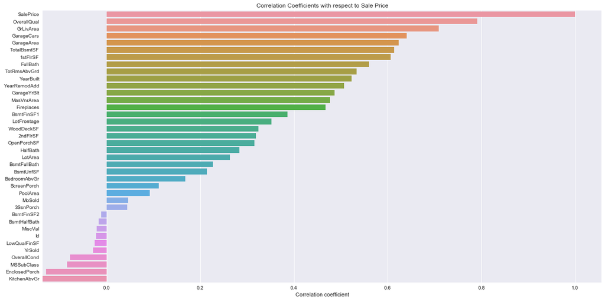

```python
fig, ax = plt.subplots(figsize=(20,10))
ax = sns.barplot(y = ccof.index, x =ccof.values )
ax.set_xlabel("Correlation coefficient")
ax.set_title("Correlation Coefficients with respect to Sale Price")
```

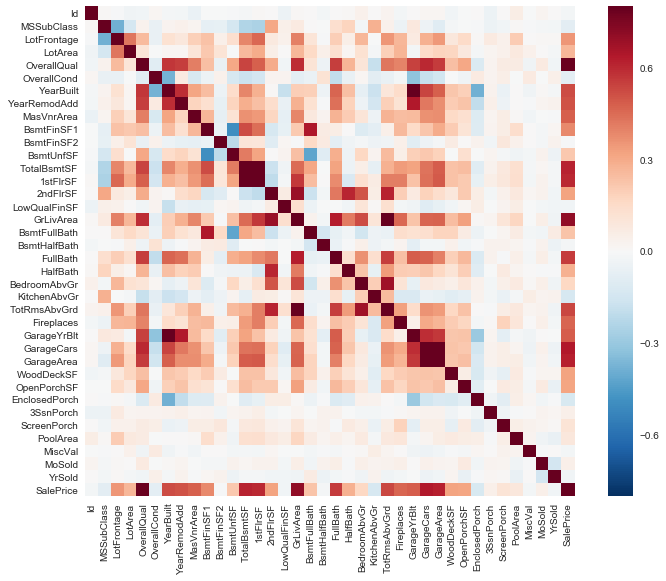

```python
#correlation matrix
corrmat = data_train.corr()
f, ax = plt.subplots(figsize=(12, 9))
sns.heatmap(corrmat, vmax=.8, square=True);
```

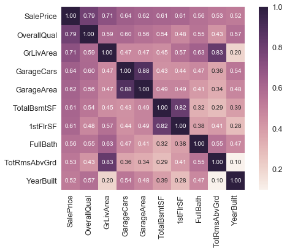

```python
#saleprice correlation matrix
k = 10 #number of variables for heatmap

cols = corrmat.nlargest(k, 'SalePrice')['SalePrice'].index
cm = np.corrcoef(data_train[cols].values.T)
sns.set(font_scale=1.25)
hm = sns.heatmap(cm, cbar=True, annot=True, square=True, fmt='.2f', annot_kws={'size': 10}, yticklabels=cols.values, xticklabels=cols.values)
plt.show()
```

## Missing data

```python
def show_missing():
    missing = data_train.columns[data_train.isnull().any()].tolist()
    return missing
```

```python
show_missing()
```

```
['LotFrontage',
 'Alley',
 'MasVnrType',
 'MasVnrArea',
 'BsmtQual',
 'BsmtCond',
 'BsmtExposure',
 'BsmtFinType1',
 'BsmtFinType2',
 'Electrical',
 'FireplaceQu',
 'GarageType',
 'GarageYrBlt',
 'GarageFinish',
 'GarageQual',
 'GarageCond',
 'PoolQC',
 'Fence',
 'MiscFeature']
```

```python
total = data_train.isnull().sum()
percent = (data_train.isnull().sum()/data_train.isnull().count()).sort_values(ascending=False)
missing_data = pd.concat([corr, total, percent], axis=1, keys=['Corr', 'Total', 'Percent'])

missing_data = missing_data.sort_values('Total', ascending = False)
missing_data.head(20)
```

|  | Corr | Total | Percent |
| --- | --- | --- | --- |
| PoolQC | NaN | 1453 | 0.995205 |
| MiscFeature | NaN | 1406 | 0.963014 |
| Alley | NaN | 1369 | 0.937671 |
| Fence | NaN | 1179 | 0.807534 |
| FireplaceQu | NaN | 690 | 0.472603 |
| LotFrontage | 0.351799 | 259 | 0.177397 |
| GarageFinish | NaN | 81 | 0.055479 |
| GarageQual | NaN | 81 | 0.055479 |
| GarageType | NaN | 81 | 0.055479 |
| GarageYrBlt | 0.486362 | 81 | 0.055479 |
| GarageCond | NaN | 81 | 0.055479 |
| BsmtExposure | NaN | 38 | 0.026027 |
| BsmtFinType2 | NaN | 38 | 0.026027 |
| BsmtQual | NaN | 37 | 0.025342 |
| BsmtCond | NaN | 37 | 0.025342 |
| BsmtFinType1 | NaN | 37 | 0.025342 |
| MasVnrType | NaN | 8 | 0.005479 |
| MasVnrArea | 0.477493 | 8 | 0.005479 |
| Electrical | NaN | 1 | 0.000685 |
| MiscVal | -0.021190 | 0 | 0.000000 |

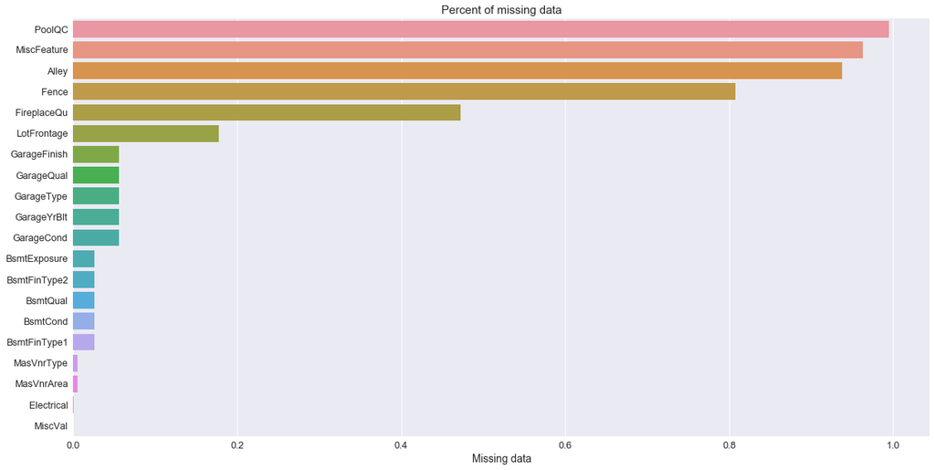

```python
k = 20
fig, ax = plt.subplots(figsize=(20,10))

missing_data_top20 = missing_data[:20]
ax = sns.barplot(y = missing_data_top20.index, x = missing_data_top20['Percent'])
ax.set_xlabel("Missing data")
ax.set_title("Percent of missing data")
```

```python
# deleting missing data
def handle_missing(data, column, value):
    data.loc[data[column].isnull(),column] = value
```

## Pool

```python
data_train['PoolArea'].describe()
```

```
count    1460.000000
mean        2.758904
std        40.177307
min         0.000000
25%         0.000000
50%         0.000000
75%         0.000000
max       738.000000
Name: PoolArea, dtype: float64
```

```python
# count sum of PoolAreas  where PoolQC == NaN

pool_areas = data_train['PoolArea'][data_train['PoolQC'].isnull()==True].sum()
print(pool_areas)
```

```
0
```

```python
handle_missing(data_train, 'PoolQC', 'None')
```

## MiscFeature

MiscFeature: Miscellaneous feature not covered in other categories

- Elev - Elevator
- Gar2 - 2nd Garage (if not described in garage section)
- Othr - Other
- Shed - Shed (over 100 SF)
- TenC - Tennis Court
- NA - None

  Replace NaN with 'None'

```python
handle_missing(data_train, 'MiscFeature', 'None' )
```

## Alley

Alley: Type of alley access to property

- Grvl - Gravel
- Pave - Paved
- NA - No alley access

Replace NaN with 'None'

```python
handle_missing(data_train, 'Alley', 'None' )
```

## Fence

Fence: Fence quality

- GdPrv - Good Privacy
- MnPrv - Minimum Privacy
- GdWo - Good Wood
- MnWw - Minimum Wood/Wire
- NA - No Fence

NA means no Fence at all simply replace NaN with 'None'

```python
handle_missing(data_train, 'Fence', 'None' )
```

## FireplaceQu

FireplaceQu: Fireplace quality

NA means no fireplace at all simply replace NaN with 'None'

```python
# just check it if true
fp_areas = data_train['Fireplaces'][data_train['FireplaceQu'].isnull()==True].sum()
print(fp_areas)
```

```
0
```

```python
handle_missing(data_train, 'FireplaceQu', 'None' )
```

## LotFrontage

- LotFrontage: Linear feet of street connected to property
- LotArea: Lot size in square feet

I assume that the missing data in LotFrontage can mean two things: eiter the property hasn't really direct access to the street. This is not common, but in some circumstances possible. Or property definitely has direct access to the street and data are simply missing.

For the first case, the proper value is simply zero, for the second case the value must be calculated or estimaded.

```python
handle_missing(data_train, 'LotFrontage', 0.0 )
```

## Garage

'GarageType', 'GarageYrBlt', 'GarageFinish', 'GarageQual', 'GarageCond',

GarageType: Garage location

```
   2Types    More than one type of garage
   Attchd    Attached to home
   Basment    Basement Garage
   BuiltIn    Built-In (Garage part of house - typically has room above garage)
   CarPort    Car Port
   Detchd    Detached from home
   NA    No Garage
```

GarageYrBlt: Year garage was built

GarageFinish: Interior finish of the garage

```
   Fin    Finished
   RFn    Rough Finished
   Unf    Unfinished
   NA    No Garage
```

GarageQual: Garage quality

```
   Ex    Excellent
   Gd    Good
   TA    Typical/Average
   Fa    Fair
   Po    Poor
   NA    No Garage
```

GarageCond: Garage condition

```
   Ex    Excellent
   Gd    Good
   TA    Typical/Average
   Fa    Fair
   Po    Poor
   NA    No Garage
```

GarageCars: Size of garage in car capacity

GarageArea: Size of garage in square feet

```python
handle_missing(data_train, 'GarageType', 'None' )
handle_missing(data_train, 'GarageYrBlt', 0.0 )
handle_missing(data_train, 'GarageFinish', 'None' )
handle_missing(data_train, 'GarageQual', 'None' )
handle_missing(data_train, 'GarageCond', 'None' )
```

## Basement

Missing data

'BsmtQual', 'BsmtCond', 'BsmtExposure', 'BsmtFinType1', 'BsmtFinType2',

BsmtQual: Evaluates the height of the basement

```
   Ex    Excellent (100+ inches)
   Gd    Good (90-99 inches)
   TA    Typical (80-89 inches)
   Fa    Fair (70-79 inches)
   Po    Poor (<70 inches
   NA    No Basement
```

BsmtCond: Evaluates the general condition of the basement

```
   Ex    Excellent
   Gd    Good
   TA    Typical - slight dampness allowed
   Fa    Fair - dampness or some cracking or settling
   Po    Poor - Severe cracking, settling, or wetness
   NA    No Basement
```

BsmtExposure: Refers to walkout or garden level walls

```
   Gd    Good Exposure
   Av    Average Exposure (split levels or foyers typically score average or above)
   Mn    Mimimum Exposure
   No    No Exposure
   NA    No Basement
```

BsmtFinType1: Rating of basement finished area

```
   GLQ    Good Living Quarters
   ALQ    Average Living Quarters
   BLQ    Below Average Living Quarters
   Rec    Average Rec Room
   LwQ    Low Quality
   Unf    Unfinshed
   NA    No Basement
```

BsmtFinType2: Rating of basement finished area (if multiple types)

```
   GLQ    Good Living Quarters
   ALQ    Average Living Quarters
   BLQ    Below Average Living Quarters
   Rec    Average Rec Room
   LwQ    Low Quality
   Unf    Unfinshed
   NA    No Basement
```

BsmtFinSF2: Type 2 finished square feet

BsmtUnfSF: Unfinished square feet of basement area

TotalBsmtSF: Total square feet of basement area

BsmtFinSF1: Type 1 finished square feet

```python
handle_missing(data_train, 'BsmtQual', 'None' )
handle_missing(data_train, 'BsmtCond', 'None' )
handle_missing(data_train, 'BsmtExposure', 'None' )
handle_missing(data_train, 'BsmtFinType1', 'None' )
handle_missing(data_train, 'BsmtFinType2', 'None' )
```

## Mansonry

MasVnrType: Masonry veneer type

```
   BrkCmn    Brick Common
   BrkFace    Brick Face
   CBlock    Cinder Block
   None        None
   Stone    Stone
```

MasVnrArea: Masonry veneer area in square feet

```python
handle_missing(data_train, 'MasVnrType', 'None' )
handle_missing(data_train, 'MasVnrArea', 0.0 )
```

## Electrical

Only one value is missing.

Use most common value.

```python
data_train['Electrical'].value_counts()
```

```
SBrkr    1334
FuseA      94
FuseF      27
FuseP       3
Mix         1
Name: Electrical, dtype: int64
```

```python
handle_missing(data_train, 'Electrical','SBrkr' )
```

```python
show_missing()
```

```
[]
```

# Data preaparation

```python
# copy data

model_data = data_train.copy()

# remove outliers
model_data = model_data.drop(model_data[(model_data['GrLivArea']>4000) & (model_data['SalePrice']<300000)].index)

model_data = pd.get_dummies(model_data)

# keep columns if datytype is number
keep_cols = model_data.select_dtypes(include = ['number']).columns
model_data = model_data[keep_cols]

target = model_data['SalePrice']
features = model_data.drop(['SalePrice', 'Id'], axis = 1)

print (target.shape)
print (features.shape)
```

```
(1458L,)
(1458, 301)
```

```python
from sklearn.ensemble import RandomForestRegressor
from sklearn.ensemble import GradientBoostingRegressor
from xgboost import XGBRegressor

batch = GridSearchBatch(features, target)

# param_grid - dict or list of dictionaries
param_grid = {'max_depth': [ 25, 30, 32, 36 ], 'n_estimators':[150, 200, 250, 275, 300, 325, 350, 375, 400 ]}
#param_grid = {'max_depth': [ 30, 32, 36, ], 'n_estimators':[275, 300, 325, ]}
#cv_scores = cross_val_score(rf_test, features, target, cv = 5, n_jobs = -1)
estimator = RandomForestRegressor(max_features = 100, oob_score=True, random_state=458)
batch.add( GridSearchObject(estimator, param_grid))

param_grid = {'max_depth': [ 25, 30, 32, 36], 'n_estimators':[150, 200, 250, 275, 300, 325, 350, 375, 400 ]}
estimator = GradientBoostingRegressor( max_features = 100,  random_state=1234)
batch.add( GridSearchObject(estimator, param_grid))


param_grid = {'max_depth': [ 2, 4, 6], 'n_estimators':[500, 1000, 1250, 1500 ]}
estimator = XGBRegressor(colsample_bytree=0.2, learning_rate=0.05, random_state = 1337 )
batch.add( GridSearchObject(estimator, param_grid))

results = batch.run()

#batch.plot()
```

```
Calculation of RandomForestRegressor took 00:07:03
Calculation of GradientBoostingRegressor took 00:15:53
Calculation of XGBRegressor took 00:02:18
```

```python
def plot(batch, max_col = 3 ):
    N = len(batch.bunch)
    max_row = 1 + N/max_col
    fig, axes = plt.subplots(nrows=max_row, ncols=max_col, figsize=(15,15))

    axes = axes.flatten()
    idx = 0
    for regr in batch.results:
        ax = axes[idx]
        plot_ax(ax, regr)
        idx += 1
    plt.tight_layout()

def plot_ax(ax,  regr ):
    # Get Test Scores Mean and std for each grid search
    name = regr['name']
    cv_results = regr['cv_results']
    grid_params = regr['grid_params']
    param_names = grid_params.keys()
    grid_param_1 = grid_params.get(param_names[0])
    grid_param_2 = grid_params.get(param_names[1])

    scores_mean = cv_results.get('mean_test_score')
    scores_mean = np.array(scores_mean).reshape(len(grid_param_2),len(grid_param_1))
    scores_sd = cv_results.get('std_test_score')
    scores_sd = np.array(scores_sd).reshape(len(grid_param_2),len(grid_param_1))

    # Param1 is the X-axis, Param 2 is represented as a different curve (color line)
    for idx, val in enumerate(grid_param_2):
        ax.set_title(name, fontweight='bold')
        ax.set_xlabel(param_names[0])
        ax.set_ylabel('CV Average Score')
        ax.legend(loc="best")
        ax.grid('on')
        ax.plot(grid_param_1, scores_mean[idx,:], '-o', label= param_names[1] + ': ' + str(val))
```

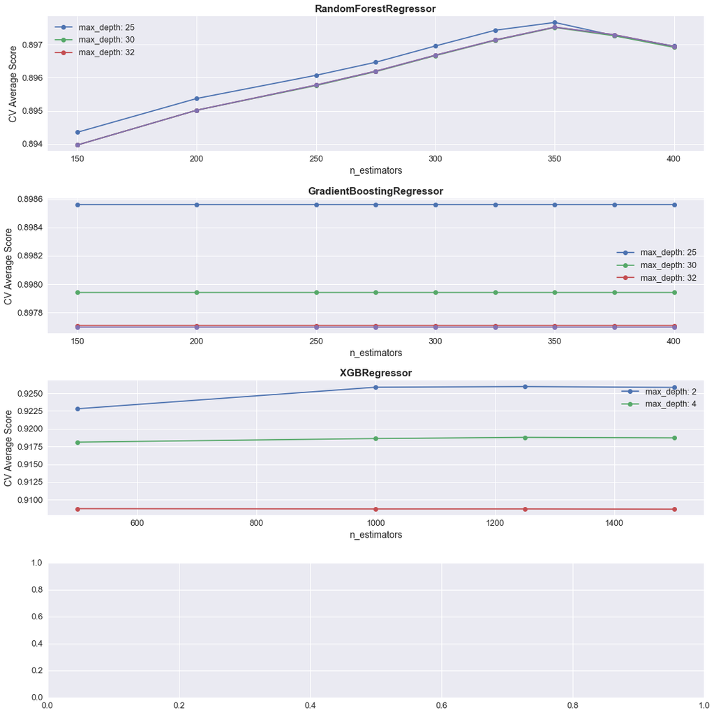

```python
#plot(batch, 1)
cv_results_dict = batch.results[0]
cv_results = cv_results_dict.get('cv_results')
params = cv_results.get('params')

plot(batch, 1)
```